# act

## en utilisant la fonction fit du package """StMoMo""" :

```r
# Model de Lee Carter en utilisant le package """StMoMo"""
# pour les paramétres éstimés on a les memes intérprétations
```

```
StMoMo: Start fitting with gnm
Initialising
Running start-up iterations..
Running main iterations.............
Done
StMoMo: Finish fitting with gnm
```

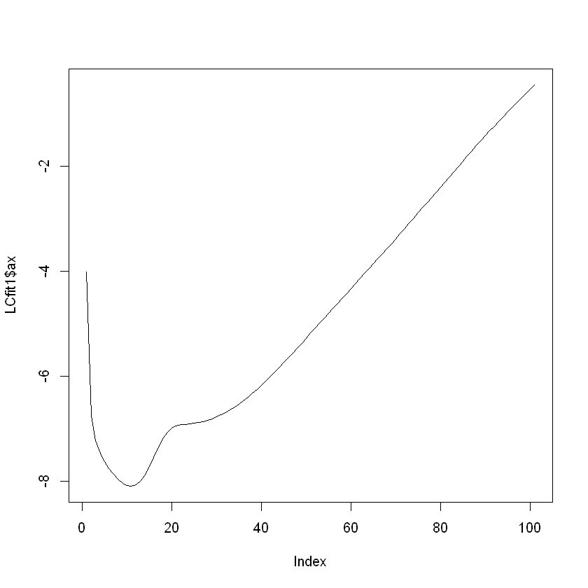

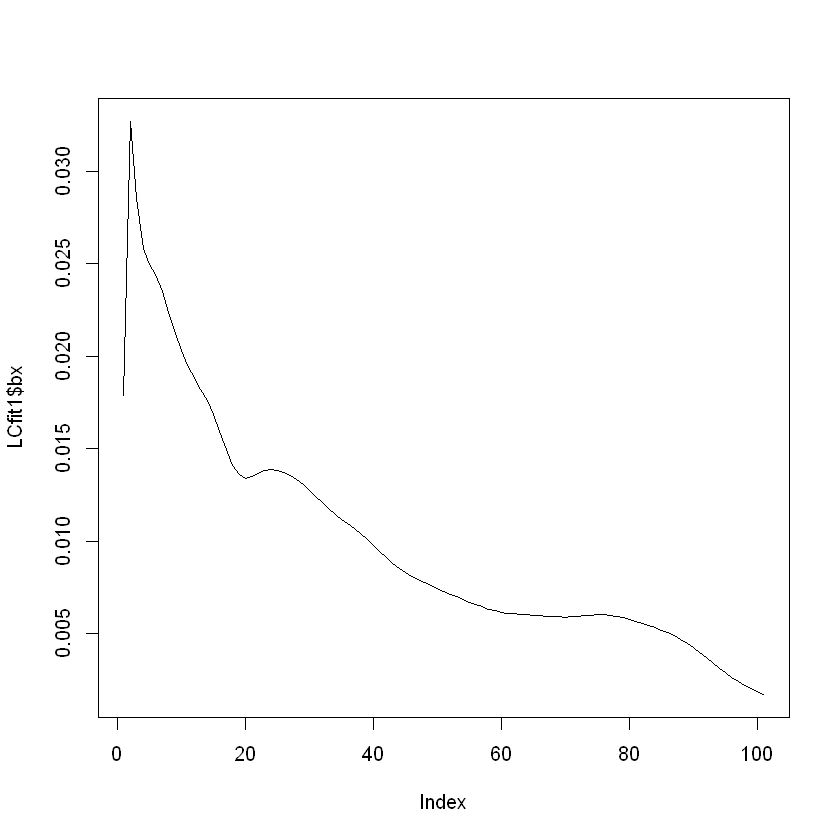

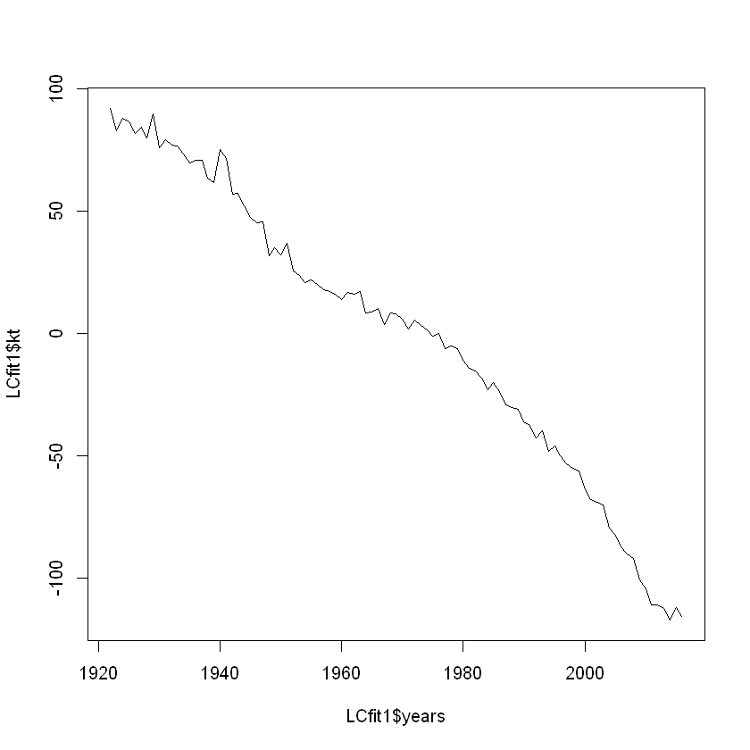

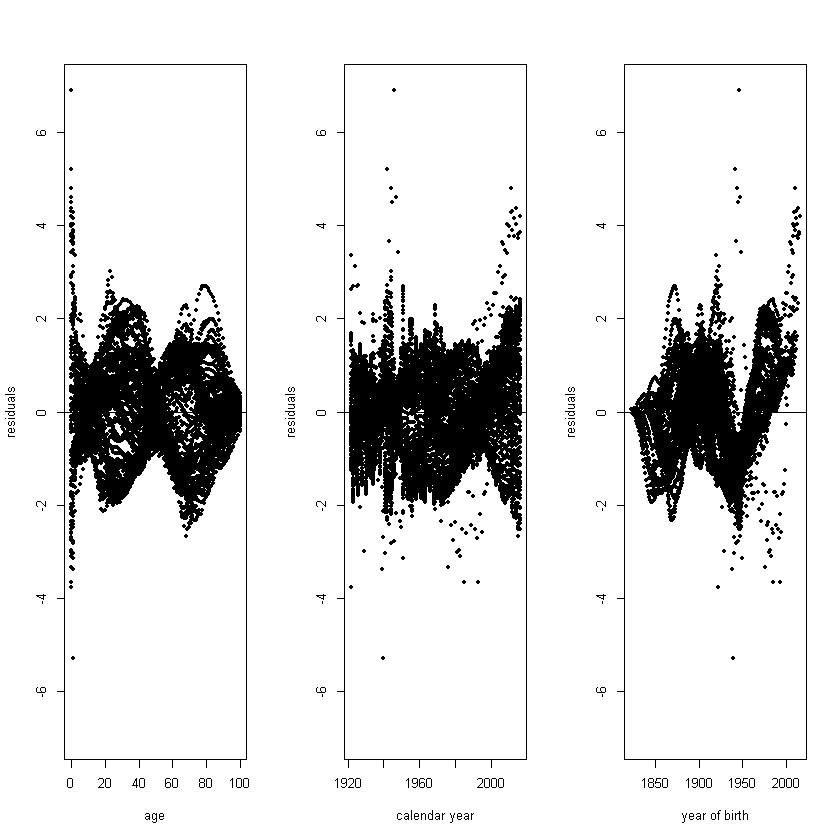

```r
#________________population totale________________ :

UK.stmomo.t<-StMoMoData(data=demogUK_ls_m ,series = "total",type="central")
#ajustement du model (fitiing) :
LC1 <- lc(link = "logit" )
LCfit1 <- fit(LC1, data = central2initial(UK.stmomo.t), ages.fit = ages.fit,  years.fit = years.fit)

#names(LCfit1)
# paramétre ax :
plot(LCfit1$ax,type='l')
# paramétre bx :
plot(LCfit1$bx,type='l')
# paramétre kt :
plot(LCfit1$years,LCfit1$kt,type='l')

# analyse desidusLelles :
LCres1 <- residuals(LCfit1)
plot(LCres1,type = "scatter") # Scatter plots of deviance residuals for models LC
```

```
StMoMo: Start fitting with gnm
Initialising
Running start-up iterations..
Running main iterations.................
Done
StMoMo: Finish fitting with gnm
```

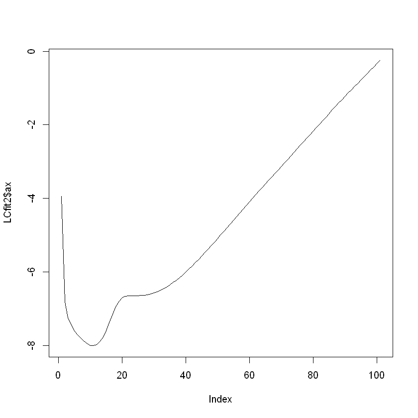

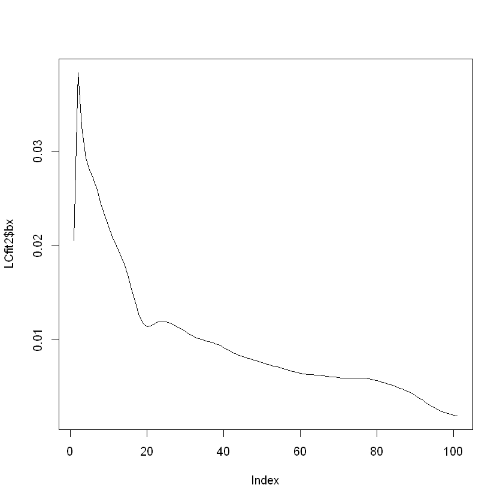

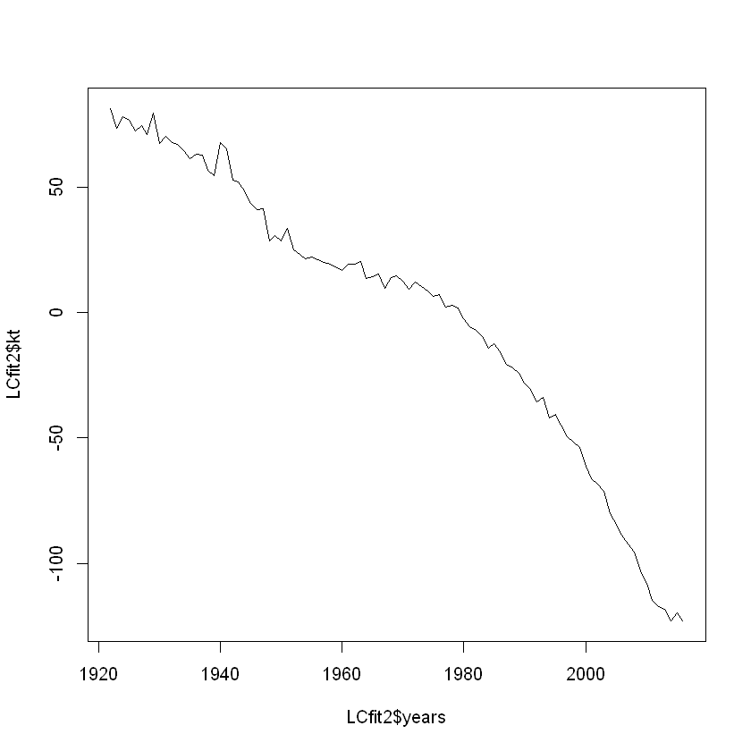

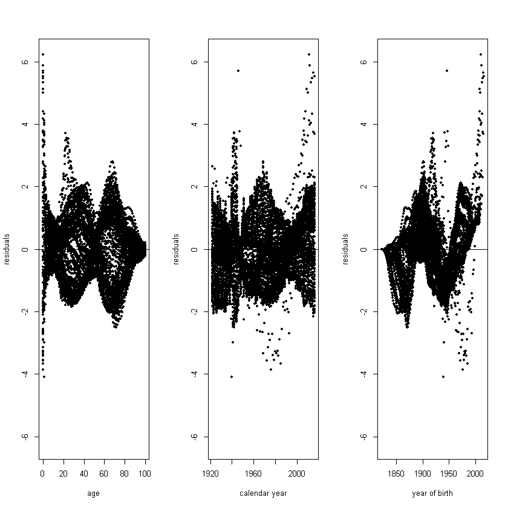

```r
#________________population masculine________________ :

UK.stmomo.m<-StMoMoData(data=demogUK_ls_m ,series = "male",type="central")
#ajustement du model (fitiing) :
LC2 <- lc(link = "logit" )
LCfit2 <- fit(LC2, data = central2initial(UK.stmomo.m), ages.fit = ages.fit,  years.fit = years.fit)

#names(LCfit2)
# paramétre ax :
plot(LCfit2$ax,type='l')
# paramétre bx :
plot(LCfit2$bx,type='l')
# paramétre kt :
plot(LCfit2$years,LCfit2$kt,type='l')

# analyse desidusLelles :
LCres2 <- residuals(LCfit2)
plot(LCres2,type = "scatter") # Scatter plots of deviance residuals for models LC
```

```
StMoMo: Start fitting with gnm
Initialising
Running start-up iterations..
Running main iterations.........
Done
StMoMo: Finish fitting with gnm
```

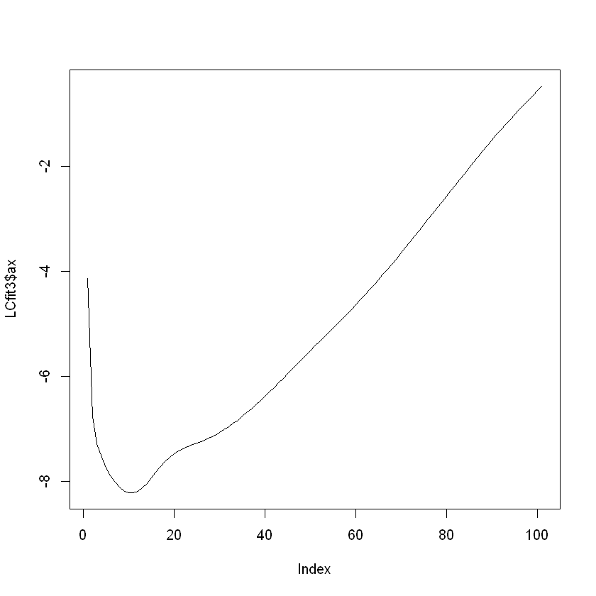

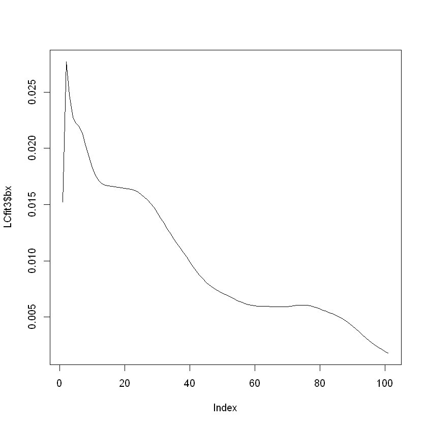

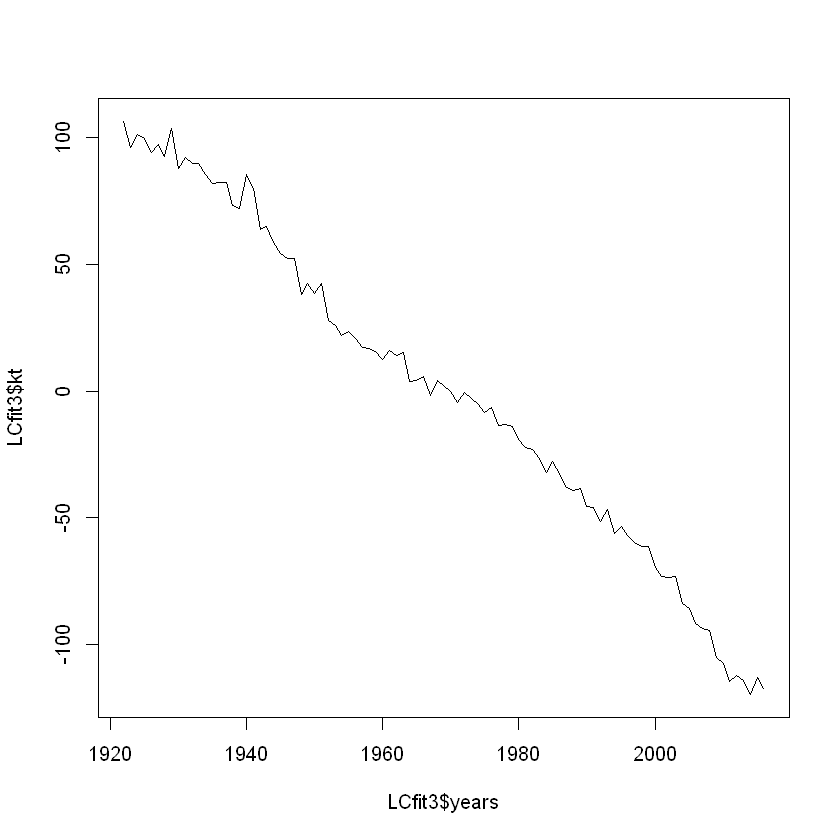

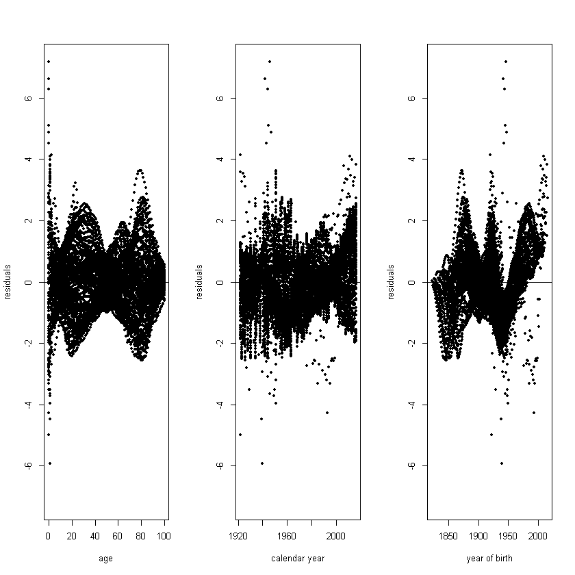

```r
#________________population féminine________________ :

UK.stmomo.f<-StMoMoData(data=demogUK_ls_m ,series = "female",type="central")
#ajustement du model (fitiing) :
LC3 <- lc(link = "logit" )
LCfit3 <- fit(LC3, data = central2initial(UK.stmomo.f), ages.fit = ages.fit,  years.fit = years.fit)

#names(LCfit3)
# paramétre ax :
plot(LCfit3$ax,type='l')
# paramétre bx :
plot(LCfit3$bx,type='l')
# paramétre kt :
plot(LCfit3$years,LCfit3$kt,type='l')

# analyse desidusLelles :
LCres3 <- residuals(LCfit3)
plot(LCres3,type = "scatter") # Scatter plots of deviance residuals for models LC
```

# Question 4 :

```r
# Affichage des log taux de mortalités historiques des femmes :
```

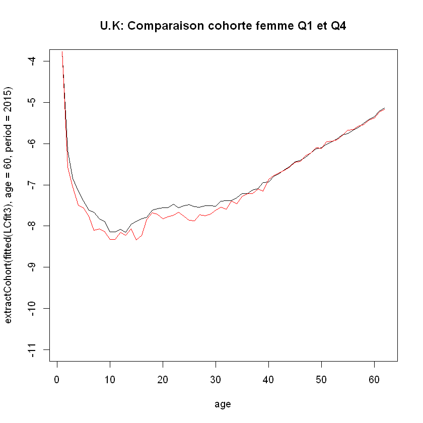

```r
plot(extractCohort(fitted(LCfit3),age=60,period=2015),
     type="l",ylim=c(-11,-4),
     main="U.K: Comparaison cohorte femme Q1 et Q4",
     xlab="age")

lines(cohort(1955, (demogUK$rate$female), log=T),
      col="red",
      type="l",
      ylim=c(-11,5),
      xlab = "age",
      ylab = "Taux de Mortalité")
```

```r
# en utilisant de la fonction extractCohort, on a remarque que l'affichage des log taux de mortalités historiques semble aux taux estimés
# en question 1.
```

```r
# Affichage des log taux de mortalités historiques des hommes :
```

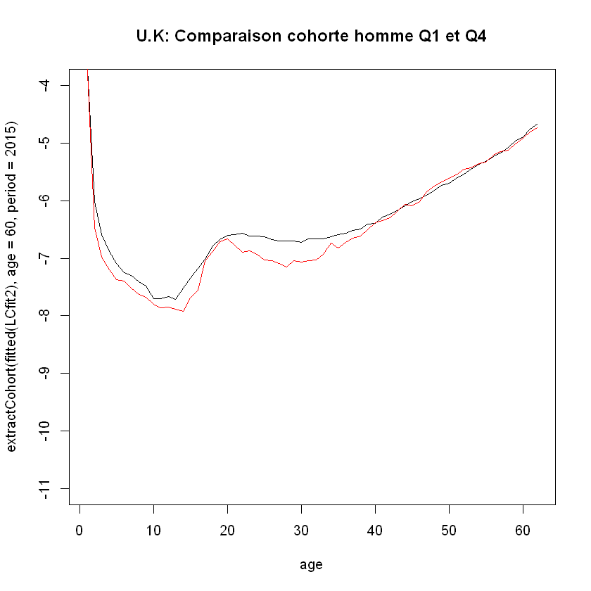

```r
plot(extractCohort(fitted(LCfit2),age=60,period=2015),
     type="l",ylim=c(-11,-4),
     main="U.K: Comparaison cohorte homme Q1 et Q4",
     xlab="age")


lines(cohort(1955, (demogUK$rate$male), log=T),
      col="red",
      type="l",
      ylim=c(-11,5),
      xlab = "age",
      ylab = "Taux de Mortalité")
```

```r
# en utilisant de la fonction extractCohort, on a remarque que l'affichage des log taux de mortalités historiques semble aux taux estimés
# en question 1.
```

# Question 5 :

```r
#________________population totale________________ :
```

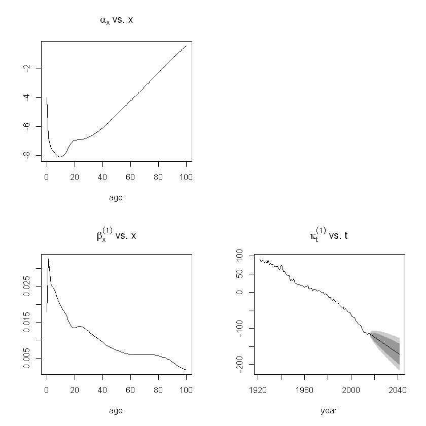

```r
horizon=25
LCfor.t <- forecast(LCfit1, h = horizon)
plot(LCfor.t)

rates.t<-cbind(demogUK$rate$total[0:100,],LCfor.t$rate[0:100,])
```

```r
#on peut changer la période de calibration et voir regarder à
#chaque fois l'intervalle de confiance'
```

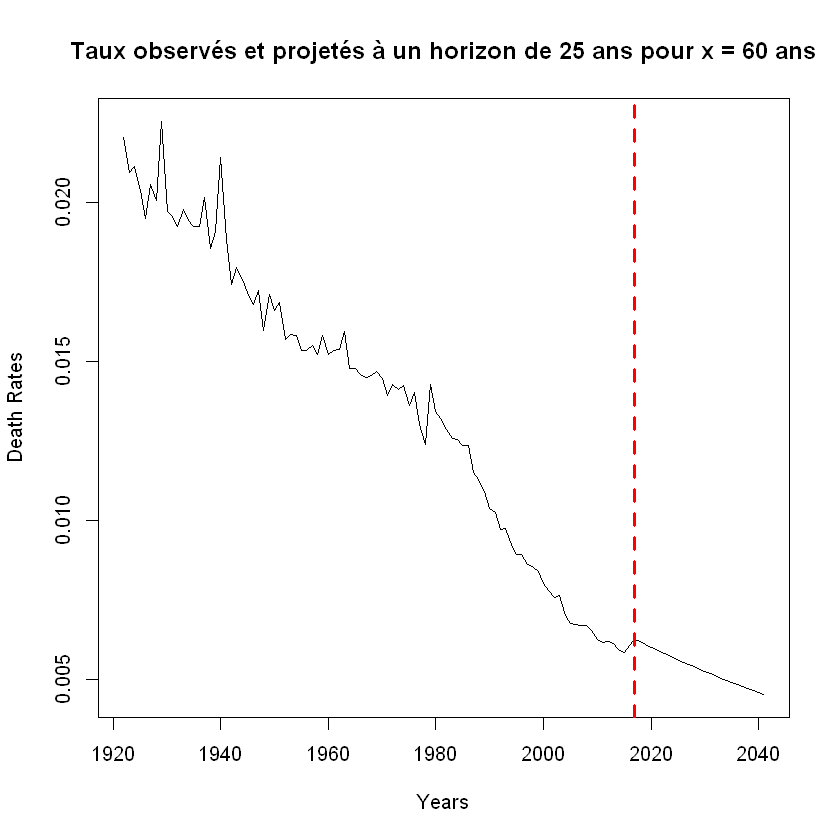

```r
plot(seq(min(demogUK$year),max(demogUK$year)+25),
     rates.t[60,],
     xlab="Years",
     ylab="Death Rates",
     type="l",
     main="Taux observés et projetés à un horizon de 25 ans pour x = 60 ans")

abline(v = 2017 , col="red" ,lwd=3, lty=2)
```

```r
#________________population masculine________________ :
```

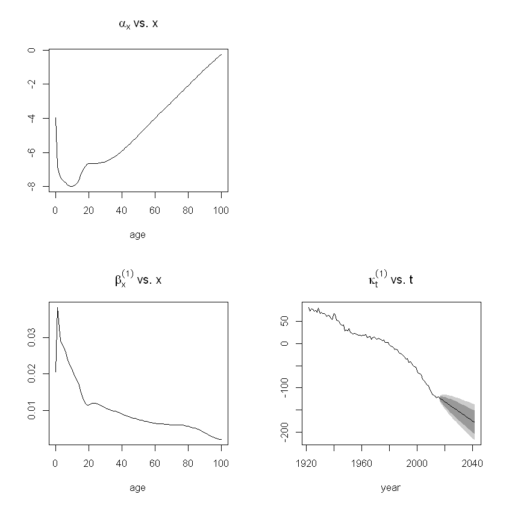

```r
horizon=25
LCfor.m <- forecast(LCfit2, h = horizon)
plot(LCfor.m)

rates.m<-cbind(demogUK$rate$male[0:100,],LCfor.m$rate[0:100,])
```

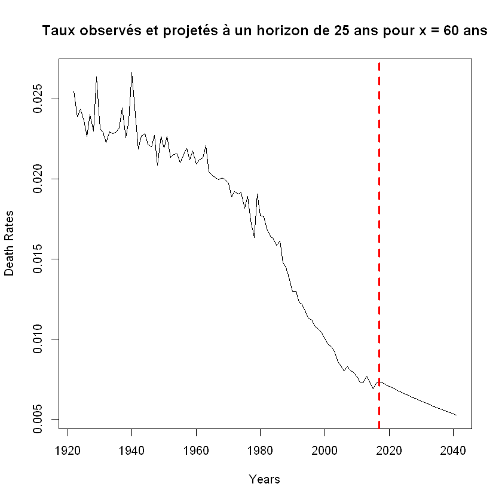

```r
plot(seq(min(demogUK$year),max(demogUK$year)+25),
     rates.m[60,],
     xlab="Years",
     ylab="Death Rates",
     type="l",
     main="Taux observés et projetés à un horizon de 25 ans pour x = 60 ans")

abline(v = 2017 , col="red" ,lwd=3, lty=2)
```

```r
#________________population féminine________________ :
```

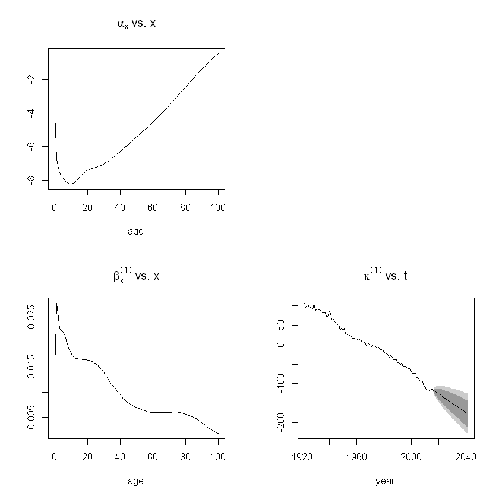

```r
horizon=25
LCfor.f <- forecast(LCfit3, h = horizon)
plot(LCfor.f)

rates.f<-cbind(demogUK$rate$female[0:100,],LCfor.f$rate[0:100,])
```

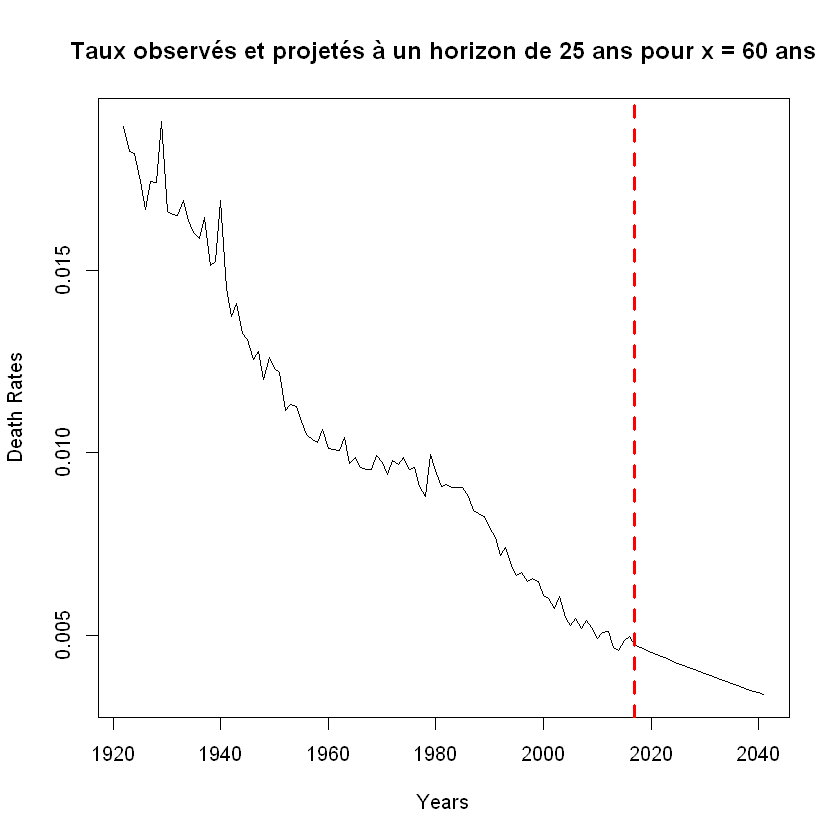

```r
plot(seq(min(demogUK$year),max(demogUK$year)+25),
     rates.f[60,],
     xlab="Years",
     ylab="Death Rates",
     type="l",
     main="Taux observés et projetés à un horizon de 25 ans pour x = 60 ans")

abline(v = 2017 , col="red" ,lwd=3, lty=2)
```

```r
# La projection centrale est une estimation moyenne sur 25 ans des taux de mortalité. Cette quantité peut      ###
# donner une idée sur la projection totale.
```

# Question 6 :

```r
# Affichage des log taux de mortalités historiques et projetés pour les deux cohortes, à partir de 2005 :
```

```r
#________________population totale________________ :
```

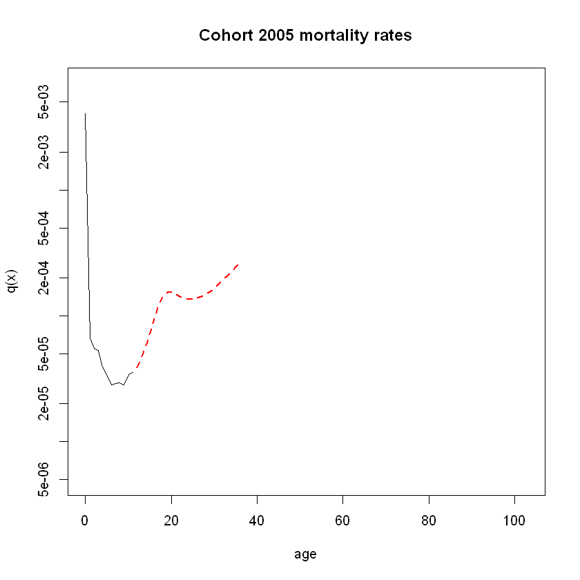

```r
#plotting historical fitted rates, until max(years.fit) =2015
chosen_cohort=2005         #doit appartenir aux years de LCfit
plot(0:11, extractCohort(fitted(LCfit1, type = "rates"),  #x = 0: max(years.fit)-chosen_cohort
       cohort = chosen_cohort),
       type = "l", log = "y", xlab = "age", ylab = "q(x)",
       main = paste(c("Cohort",toString(chosen_cohort),"mortality rates"), collapse = " "),
       xlim = c(0,103), ylim = c(0.000005, 0.007))

#adding fitted projections
lines(12:36, extractCohort(LCfor.t$rates, cohort = chosen_cohort), # x = l'âge suivant:max(years.fit)+h - chosen_cohort
      lty = 2, lwd=2, col="red")
```

```r
#________________1ére chorte : hommes nées en 2005________________ :
```

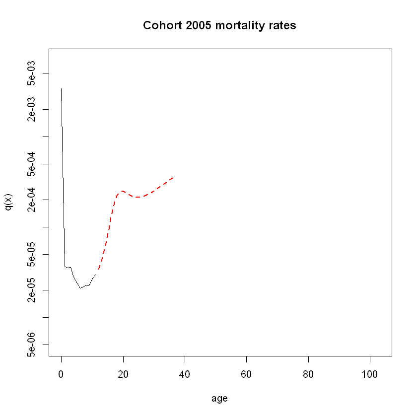

```r
#plotting historical fitted rates, until max(years.fit) =2015
chosen_cohort=2005         #doit appartenir aux years de LCfit
plot(0:11, extractCohort(fitted(LCfit2, type = "rates"),  #x = 0: max(years.fit)-chosen_cohort
       cohort = chosen_cohort),
       type = "l", log = "y", xlab = "age", ylab = "q(x)",
       main = paste(c("Cohort",toString(chosen_cohort),"mortality rates"), collapse = " "),
       xlim = c(0,103), ylim = c(0.000005, 0.007))

#adding fitted projections
lines(12:36, extractCohort(LCfor.m$rates, cohort = chosen_cohort), # x = l'âge suivant:max(years.fit)+h - chosen_cohort
      lty = 2, lwd=2, col="red")
```

```r
#________________1ére chorte : femmes nées en 2005________________ :
```

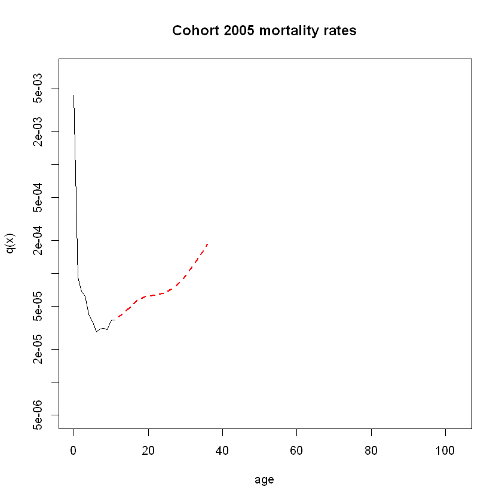

```r
#plotting historical fitted rates, until max(years.fit) =2015
chosen_cohort=2005         #doit appartenir aux years de LCfit
plot(0:11, extractCohort(fitted(LCfit3, type = "rates"),  #x = 0: max(years.fit)-chosen_cohort
       cohort = chosen_cohort),
       type = "l", log = "y", xlab = "age", ylab = "q(x)",
       main = paste(c("Cohort",toString(chosen_cohort),"mortality rates"), collapse = " "),
       xlim = c(0,103), ylim = c(0.000005, 0.007))

#adding fitted projections
lines(12:36, extractCohort(LCfor.f$rates, cohort = chosen_cohort), # x = l'âge suivant:max(years.fit)+h - chosen_cohort
      lty = 2, lwd=2, col="red")
```

```r
# On remaque que les log taux de mortalités historiques et projetés avec le modéle de Lee Carter refléte réellement la vrai vie d'un Homme
# sans avoir recours a des evénements  qui vont perturber cet résultat
```

# Question 7 :

- Calculer la valeur actuelle probable du contrat (à la date de début du contract) en différenciant selon que l’assuré est un homme ou une femme. Qu’observe-t-on ?

  ===> date de début du contract = 2015
- NB : Dans cette partie pour calculer les valeurs actuelles probables , on doit construire alors des tables actuarielles (actuarial tables) c'est pourquoi à partir de cette question, on va optez a l'extraction directe de deux colonnes "age" et "lx" des a partir Tables de survie(Life tables) des fichiers suivants :
  - "bltper_1x1.txt" : United Kingdom, Life tables (period 1x1), Total
  - "mltper_1x1.txt" : United Kingdom, Life tables (period 1x1), Males
  - "fltper_1x1.txt" : United Kingdom, Life tables (period 1x1), Females

```r
# Création des table actuarielles :
```

```r
# changement du dossier du travail et spécification du chemin d'accès au dossier souhaité (contenant les fichiers a utiliser)
setwd("C:/Users/LEGION/Desktop/Projet Actuariat/ok")
```

```r
library(lifecontingencies)
```

### male :

```r
MaleUK<-read.table(file="mltper_1x1.txt", header = TRUE,skip = 1, sep = "", dec = ".")
```

```r
MaleUK15_16<-MaleUK[which(MaleUK$Year == 2015),names(MaleUK)]
```

```r
df_m<-data.frame(MaleUK15_16)
```

```r
x_m<-df_m$Age
lx_m<-df_m$lx
```

```r
# transformation de la lifetable en table actuarielle :
tb_act_m <-new("actuarialtable",x=x_m,lx=lx_m,name="UK_male") # interest=3/100 par defaut
```

```r
#espérance de vie pour l'age 60 :
ESP_m=exn(tb_act_m,x=60)
```

```r
#probabilité de survie pour l'age 60 jusqu'a la fin du contrat :
P_Survie_m=pxt(tb_act_m,x=60, t=30)
```

```r
#probabilité de décès pour l'age 60 jusqu'a la fin du contrat :
P_deces_m=qxt(tb_act_m,x=60, t=30)
```

```r
# vap :
VAP_m = axn(tb_act_m, x=60, n=30)
```

```r
#Prime pure : (exigence question 8)
Prime_Pure_m=axn(tb_act_m, x=60, m=30)/axn(tb_act_m, x=60, m=1,n=30)
Prime_Pure_m
```

0.024976828326

### female :

```r
FemaleUK<-read.table(file="fltper_1x1.txt", header = TRUE,skip = 1, sep = "", dec = ".")
```

```r
FemaleUK15_16<-FemaleUK[which(FemaleUK$Year == 2015),names(FemaleUK)]
```

```r
df_f<-data.frame(FemaleUK15_16)
```

```r
x_f<-df_f$Age
lx_f<-df_f$lx
```

```r
# transformation de la lifetable en table actuarielle :
tb_act_f <-new("actuarialtable",x=x_f,lx=lx_f,name="UK_female") # interest=3/100 par defaut
```

```r
#espérance de vie pour l'age 60 :
ESP_f=exn(tb_act_f,x=60)
```

```r
#probabilité de survie pour l'age 60 jusqu'a la fin du contrat :
P_Survie_f=pxt(tb_act_f, x=60, t=30)
```

```r
#probabilité de décès pour l'age 60 jusqu'a la fin du contrat :
P_deces_f=qxt(tb_act_f, x=60, t=30)
```

```r
# vap :
VAP_f = axn(tb_act_f, x=60, n=30)
```

```r
#Prime pure : (exigence question 8)
Prime_Pure_f=axn(tb_act_f, x=60, m=30)/axn(tb_act_f, x=60, m=1,n=30)
Prime_Pure_f
```

0.0381800186848923

```r
# observation :
c(VAP_m,VAP_f)
```

1. 15.8490674816521

2. 16.9570119198997

```r
# on observe que la valeur actuelle probable selon que l’assuré est un homme est inférieur à la valeur actuelle probable selon que l’assuré
# est une femme
```

# Question 8 :

```r
library(lifecontingencies)
```

```r
# Création de la table actuarielle totale :
```

```r
# total :
```

```r
TotalUK<-read.table(file="bltper_1x1.txt", header = TRUE,skip = 1, sep = "", dec = ".")
```

```r
TotalUK15_16<-TotalUK[which(TotalUK$Year == 2015),names(TotalUK)]
```

```r
df_t<-data.frame(TotalUK15_16)
```

```r
x_t<-df_t$Age
lx_t<-df_t$lx
```

```r
# transformation de la lifetable en table actuarielle :
tb_act_t <- new("actuarialtable",x=x_t,lx=lx_t,name="UK_total") # interest=3/100 par defaut
```

```r
#espérance de vie pour l'age 60 :
ESP_t=exn(tb_act_t,x=60)
```

```r
#probabilité de survie pour l'age 60 jusqu'a la fin du contrat :
P_Survie_t=pxt(tb_act_t, x=60, t=30)
```

```r
#probabilité de décès pour l'age 60 jusqu'a la fin du contrat :
P_deces_t=qxt(tb_act_t, x=60, t=30)
```

```r
# vap :
VAP_t = axn(tb_act_t, x=60, n=30)
```